# hw04

Nima Jamshidi

2019-10-16 17:30:00 +0800

## Exercise 1: Explain the value of the here::here package

*As default here::here package uses the directory of project as the root directory, in contrast to the default relative paths that are considered in R. When you run a .Rmd file in a subdirectory of the project, by using the directory of project as the root directory, here::here() function makes life easier if you want to access to other subdirectories of the project. Moreover if you run the script out of the project environment, you might find some difficulties using basic R functions. For example, in .R files, the relative path would change and that would make some troubles. However, here::here function still uses the directory of project as its root directory, since it is looking for .Rproj file.*

## Exercise 2: Factor management

```r
gapminder_wo_Oceania <- gapminder %>%
  filter(continent!="Oceania") %>%
  droplevels()
nrow1 <- nrow(gapminder)
nlevels1 <- nlevels(gapminder$continent)
levels1 <- levels(gapminder$continent)
nrow2 <- nrow(gapminder_wo_Oceania)
nlevels2 <- nlevels(gapminder_wo_Oceania$continent)
levels2 <- levels(gapminder_wo_Oceania$continent)

gapminder_wo_Oceania_reordered <- gapminder_wo_Oceania %>%
  mutate(continent=fct_reorder(continent,lifeExp,(var)))
levels3=levels(gapminder_wo_Oceania_reordered$continent)
```

```r
cat(" \n")
  cat("**Before:**")
  cat(" \n")
gapminder_wo_Oceania %>% arrange(continent) %>% DT::datatable()
cat(" \n")
  cat("**After:**")
  cat(" \n")
gapminder_wo_Oceania_reordered %>% arrange(continent) %>% DT::datatable()

  cat(" <div style= \"float: left;width: 50%; \"> ")
gapminder_wo_Oceania %>%
  ggplot() +
  geom_bar(aes(continent)) +
  coord_flip()+
  theme_bw() +
  xlab("Continent")+ylab("Number of entries") +
  ggtitle("Before")
cat(" </div> ")
cat(" <div style= \"float: right;width: 50%; \"> ")
gapminder_wo_Oceania %>%
  ggplot() +
  geom_bar(aes(fct_reorder(continent, lifeExp, var))) +
  coord_flip()+
  theme_bw() +
  xlab("Continent")+ylab("Number of entries")  +
  ggtitle("After")
cat(" </div> ")
cat(" <div style= \"clear:both; \"></div> ")
```

I will try to filter out the rows with Oceania as their continent from the gapminder dataset and drop the respective level. The number of rows, the number of levels, and the levels before and after are shown bellow:

**Before:**

number of rows= 1704

number of levels= 5

levels: Africa, Americas, Asia, Europe, Oceania

**After:**

number of rows= 1680

number of levels= 4

levels: Africa, Americas, Asia, Europe

Now I will reorder the continent variable by the variance of life expectancy. Then I will arrange the datasets and show the effect of reordering on arranging the datasets by the continent variable. It can be observed that after reordering, arrange function arranges the dataset based on the new order. Furthermore, the plots number of entries for each continent before and after of the reordering are shown.

The arrangement of levels after reordering is as follows:

levels: Europe, Africa, Americas, Asia

**Before:**

|  | country | continent | year | lifeExp | pop | gdpPercap |
| --- | --- | --- | --- | --- | --- | --- |
| 1 | Algeria | Africa | 1952 | 43.077 | 9279525 | 2449.008185 |
| 2 | Algeria | Africa | 1957 | 45.685 | 10270856 | 3013.976023 |
| 3 | Algeria | Africa | 1962 | 48.303 | 11000948 | 2550.81688 |
| 4 | Algeria | Africa | 1967 | 51.407 | 12760499 | 3246.991771 |
| 5 | Algeria | Africa | 1972 | 54.518 | 14760787 | 4182.663766 |
| 6 | Algeria | Africa | 1977 | 58.014 | 17152804 | 4910.416756 |
| 7 | Algeria | Africa | 1982 | 61.368 | 20033753 | 5745.160213 |
| 8 | Algeria | Africa | 1987 | 65.799 | 23254956 | 5681.358539 |
| 9 | Algeria | Africa | 1992 | 67.744 | 26298373 | 5023.216647 |
| 10 | Algeria | Africa | 1997 | 69.152 | 29072015 | 4797.295051 |

[output cut: 1670 more lines]

**After:**

|  | country | continent | year | lifeExp | pop | gdpPercap |
| --- | --- | --- | --- | --- | --- | --- |
| 1 | Albania | Europe | 1952 | 55.23 | 1282697 | 1601.056136 |
| 2 | Albania | Europe | 1957 | 59.28 | 1476505 | 1942.284244 |
| 3 | Albania | Europe | 1962 | 64.82 | 1728137 | 2312.888958 |
| 4 | Albania | Europe | 1967 | 66.22 | 1984060 | 2760.196931 |
| 5 | Albania | Europe | 1972 | 67.69 | 2263554 | 3313.422188 |
| 6 | Albania | Europe | 1977 | 68.93 | 2509048 | 3533.00391 |
| 7 | Albania | Europe | 1982 | 70.42 | 2780097 | 3630.880722 |
| 8 | Albania | Europe | 1987 | 72 | 3075321 | 3738.932735 |
| 9 | Albania | Europe | 1992 | 71.581 | 3326498 | 2497.437901 |
| 10 | Albania | Europe | 1997 | 72.95 | 3428038 | 3193.054604 |

[output cut: 1670 more lines]

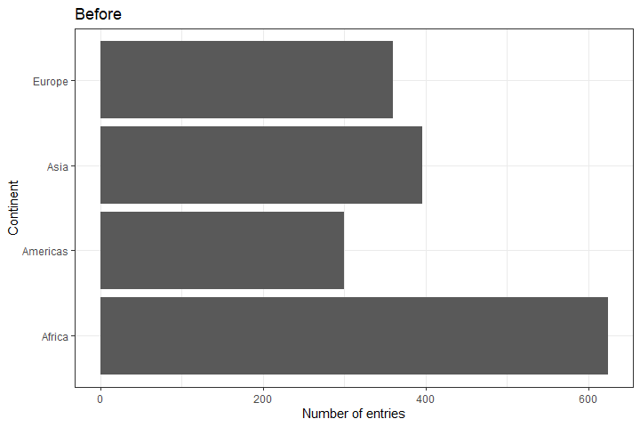

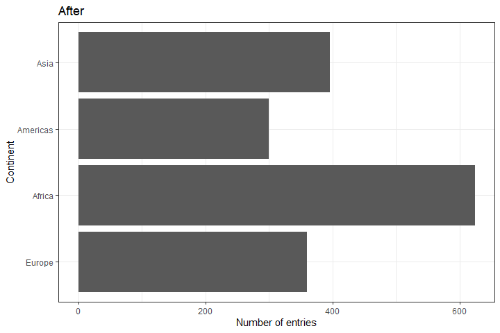